# Project - Assessing Home Value

Home valuation data set from Boulder Colorado County exploring the following:

### Part 1: Data Insights

Perform exploratory data analysis on the data set and generate insights.

### Part 2: Estimate Home Values

Determine the home valuation using a KNN algorithm to value new homes based on similar home sales. By law, residential properties must be valued by using a "market approach". This predicts the price a property would bring on the open market in a transaction between a willing, informed, and knowledgeable buyer and seller. A property can be valued through the process of analyzing comparable sales. A comparable sale is any qualified sale in the last 5 years (January 2015 - December 2020).

The central factors used by the Assessors for property valuation are:

- Location
- Living Area (SQFT)
- Age of the Home
- Finished Basement

### Part 3: Ethics Review

Fairness and accuracy are vitally important. If the assessed values are too high, the property owners will overpay in taxes. If the assessed values are too low then we may fall short of the capital needed to cover the budget approved by legislators. As such, thinking through the impact of how we predict home prices is vitial.

## Part 1: EDA

### Goal

Perform EDA on the property valuations for "1-Story" and "2-3 Story" single family residential buildings. Identify at least 2 key insights and/or graphs that tell a story about the valuations for these properties .

### Get the data

1. Read in the following data:
   - buildings.csv
   - land.csv
   - values.csv
   - owner_addresses.csv
2. Adjust the structure of our data as necessary (joins, drop unneeded columns, add features, etc).
3. Inspect and handle missing values as necessary.

```python
import seaborn as sns
import pandas as pd
import matplotlib.pyplot as plt
import numpy as np

# Allow for plots to display inline
%matplotlib inline
```

Load and clean the data sets:

```python
buildings = pd.read_csv("../data-sets/buildings.csv")
values = pd.read_csv("../data-sets/values.csv")
owner_add = pd.read_csv("../data-sets/owner_address.csv")
```

```python
buildings.head(3)
```

|  | strap | bld_num | section_num | designCode | designCodeDscr | qualityCode | qualityCodeDscr | bldgClass | bldgClassDscr | ConstCode | ... | ExtWallDscrPrim | ExtWallSec | ExtWallDscrSec | IntWall | IntWallDscr | Roof_Cover | Roof_CoverDscr | Stories | UnitCount | status_cd |
| --- | --- | --- | --- | --- | --- | --- | --- | --- | --- | --- | --- | --- | --- | --- | --- | --- | --- | --- | --- | --- | --- |
| 0 | R0000005 | 1 | 1 | 10 | 1 Story - Ranch | 30 | AVERAGE | 1212 | SINGLE FAM RES IMPROVEMENTS | 320 | ... | Brick Veneer | NaN | NaN | 1130.0 | Drywall | 1210.0 | Asphalt | NaN | NaN | A |
| 1 | R0000006 | 1 | 1 | 20 | 2-3 Story | 32 | AVERAGE ++ | 1212 | SINGLE FAM RES IMPROVEMENTS | 310 | ... | Frame Wood/Shake | NaN | NaN | 1120.0 | Plaster | 1210.0 | Asphalt | NaN | NaN | A |
| 2 | R0000008 | 1 | 1 | 10 | 1 Story - Ranch | 31 | AVERAGE + | 1212 | SINGLE FAM RES IMPROVEMENTS | 320 | ... | Brick Veneer | NaN | NaN | 1130.0 | Drywall | 1210.0 | Asphalt | NaN | NaN | A |

3 rows × 42 columns

```python
values.head(3)
```

|  | strap | tax_yr | bldAcutalVal | LandAcutalVal | xfActualVal | totalActualVal | landAssessedVal | bldAssessedVal | xfAssessedVal | totalAssessedVal | status_cd |
| --- | --- | --- | --- | --- | --- | --- | --- | --- | --- | --- | --- |
| 0 | R0000005 | 2021 | 73140 | 658260 | NaN | 731400 | 47066.0 | 5230.0 | NaN | 52296 | A |
| 1 | R0000006 | 2021 | 354100 | 724400 | NaN | 1078500 | 51795.0 | 25318.0 | NaN | 77113 | A |
| 2 | R0000008 | 2021 | 222700 | 668300 | NaN | 891000 | 47783.0 | 15923.0 | NaN | 63706 | A |

```python
owner_add.head(3)
```

|  | strap | str_pfx | str_num | str | str_sfx | city | sub_code | sub_dscr | section | township | range | nh | mill_levy |
| --- | --- | --- | --- | --- | --- | --- | --- | --- | --- | --- | --- | --- | --- |
| 0 | R0000005 | NaN | 3030.0 | DOVER | DR | BOULDER | 3459.0 | HIGHLAND PARK 5 - BO | 5.0 | 1S | 70.0 | 160.0 | 87.045 |
| 1 | R0000006 | NaN | 1310.0 | HAWTHORN | AVE | BOULDER | 6255.0 | PARSONS PARK - BO | 19.0 | 1N | 70.0 | 115.0 | 87.045 |
| 2 | R0000008 | NaN | 2002.0 | COLUMBINE | AVE | BOULDER | 3822.0 | INTERURBAN PARK - BO | 6.0 | 1S | 70.0 | 102.0 | 87.045 |

```python
buildings.drop(columns = ['status_cd','bldgClass','Stories','Ac','AcDscr','Heating','HeatingDscr','ExtWallPrim','ExtWallDscrPrim','ExtWallSec','ExtWallDscrSec','IntWall','IntWallDscr','Roof_Cover','Roof_CoverDscr','UnitCount'], inplace = True)
```

```python
buildings.columns = buildings.columns.str.capitalize()
```

Remove rows where total sqft is less than 100

```python
buildings= buildings.drop(buildings[buildings.Totalfinishedsf < 100].index)
```

```python
values.drop(columns=['xfActualVal','xfAssessedVal','status_cd'], inplace = True)
```

```python
values.columns = values.columns.str.capitalize()
```

```python
owner_add.columns = owner_add.columns.str.capitalize()
```

Merge data sets: Buildings, Owner_add and Values

```python
Building_add = buildings.merge(owner_add,
                           how = 'inner',
                           on = 'Strap')
```

```python
Building_add = Building_add.merge(values,
                           how = 'inner',
                           on = 'Strap')
```

Explore variables: Designcodedscr(1Story or 2-3Story), Total finished sqft, City, TotalactualVal, Effectiveyear(for home age) and Total Assessed Val

```python
Building_add_set1 = Building_add[['Designcodedscr','Totalfinishedsf','City','Totalactualval','Effectiveyear','Totalassessedval','Nh','Bsmttypedscr']].copy()
```

```python
hg = 2021-Building_add_set1['Effectiveyear']
Building_add_set1['Homeage'] = hg
```

```python
Building_add_set1['Basement'] = Building_add_set1['Bsmttypedscr'].str.extract('( FINISHED)')
```

```python
Building_add_set1['Basement'] = Building_add_set1['Basement'].fillna("UNFINSHED/NOBASEMENT")
```

```python
Building_add_set1['Bsmntflg'] = np.where(
    Building_add_set1['Basement'] == 'UNFINSHED/NOBASEMENT', 0, 1)
```

```python
Building_add_set1.head(3)
```

|  | Designcodedscr | Totalfinishedsf | City | Totalactualval | Effectiveyear | Totalassessedval | Nh | Bsmttypedscr | Homeage | Basement | Bsmntflg |
| --- | --- | --- | --- | --- | --- | --- | --- | --- | --- | --- | --- |
| 0 | 1 Story - Ranch | 1282 | BOULDER | 731400 | 1957 | 52296 | 160.0 | WALK-OUT BASEMENT FINISHED AREA | 64 | FINISHED | 1 |
| 1 | 2-3 Story | 2130 | BOULDER | 1078500 | 1985 | 77113 | 115.0 | 0 | 36 | UNFINSHED/NOBASEMENT | 0 |
| 2 | 1 Story - Ranch | 1558 | BOULDER | 891000 | 1954 | 63706 | 102.0 | 0 | 67 | UNFINSHED/NOBASEMENT | 0 |

Breaking this dataset into two: One for 1 Story Buildings, Second for 2 Story Buildings

```python
Building_add_single = Building_add_set1[Building_add_set1['Designcodedscr'] == '1 Story - Ranch'].copy()
```

```python
Building_add_double = Building_add_set1[Building_add_set1['Designcodedscr'] == '2-3 Story'].copy()
```

Explore variables:Number of Bedrooms, bathrooms, Basement, Total Actual Value and Total Assessed Value

```python
Building_add_set2 = Building_add[['Carstoragetypedscr','Nbrbedroom', 'Nbrthreeqtrbaths','Nbrfullbaths','Nbrhalfbaths','Bsmttypedscr','Totalactualval','Designcodedscr','Totalassessedval']].copy()
```

```python
Building_add_set2['Basement'] = Building_add_set2['Bsmttypedscr'].str.extract('( FINISHED)')
```

```python
Building_add_set2['Basement'] = Building_add_set2['Basement'].fillna("UNFINSHED/NOBASEMENT")
```

```python
Building_add_set2 = Building_add_set2.drop(Building_add_set2[Building_add_set2.Nbrbedroom == 0].index)
```

### Explore the Data

- Explore the relationships in the data (univariate, bivariate, etc)
- Explore outliers
- Provide a summary of findings.

Descriptive Statistics:1 Story Buildings

```python
Building_add_single['Totalactualval'].describe().round(2)
```

```
count      18581.00
mean      568260.66
std       331666.10
min        32900.00
25%       344200.00
50%       492900.00
75%       701500.00
max      5378360.00
Name: Totalactualval, dtype: float64
```

```python
Building_add_single['Totalfinishedsf'].describe().round(2)
```

```
count    18581.00
mean      1379.42
std        548.66
min        104.00
25%       1008.00
50%       1266.00
75%       1664.00
max       7009.00
Name: Totalfinishedsf, dtype: float64
```

```python
Building_add_single['Homeage'].describe().round(2)
```

```
count    18581.00
mean        43.21
std         22.52
min          0.00
25%         27.00
50%         43.00
75%         55.00
max        149.00
Name: Homeage, dtype: float64
```

```python
Building_add_single['City'].value_counts(normalize=True) * 100
```

```
LONGMONT          35.627792
UNINCORPORATED    24.051450
BOULDER           22.447662
LAFAYETTE          6.506647
LOUISVILLE         4.698348
ERIE               3.239869
NEDERLAND          1.393897
LYONS              1.124805
SUPERIOR           0.425165
WARD               0.242183
JAMESTOWN          0.242183
Name: City, dtype: float64
```

Bivariate relationships:

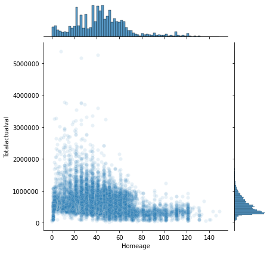

```python
sns.jointplot(data = Building_add_single,
              x = 'Homeage',
              y = 'Totalactualval',
              alpha = 0.1)
plt.ticklabel_format(style='plain', axis='y')
```

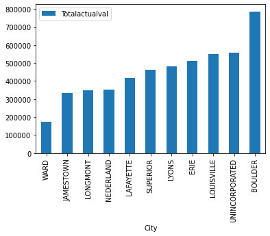

```python
Building_add_single.groupby(['City']).agg({'Totalactualval': 'median'}).sort_values(by = 'Totalactualval',ascending = True).plot(kind='bar')
```

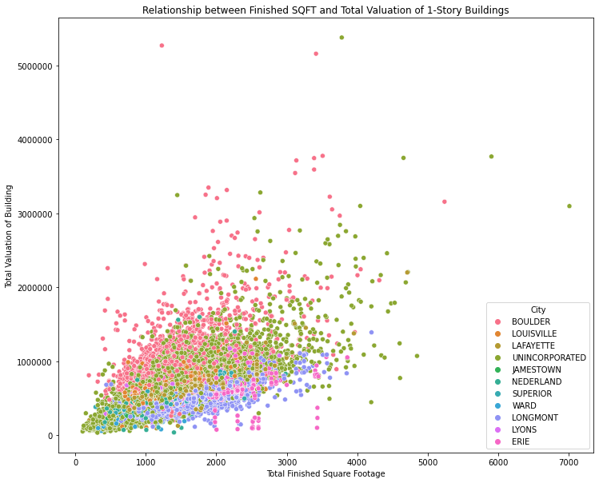

```python
fig, ax = plt.subplots(figsize=(12, 10))

ax = sns.scatterplot(x = 'Totalfinishedsf',
                     y = 'Totalactualval',
                     hue = 'City',
                     #style = 'City',
                     data = Building_add_single)

ax.set_ylabel('Total Valuation of Building')
ax.set_xlabel('Total Finished Square Footage')
ax.set_title('Relationship between Finished SQFT and Total Valuation of 1-Story Buildings')
plt.ticklabel_format(style='plain', axis='y')
```

Exploring variables for 2-3 Story Buildings

```python
Building_add_double['Totalactualval'].describe().round(2)
```

```
count      23367.00
mean      775075.43
std       487350.15
min        27100.00
25%       494200.00
50%       639700.00
75%       889050.00
max      7872360.00
Name: Totalactualval, dtype: float64
```

```python
Building_add_double['Totalfinishedsf'].describe().round(2)
```

```
count    23367.00
mean      2246.45
std        774.08
min        144.00
25%       1704.00
50%       2136.00
75%       2658.00
max      19044.00
Name: Totalfinishedsf, dtype: float64
```

```python
Building_add_double['Homeage'].describe().round(2)
```

```
count    23367.00
mean        26.56
std         15.44
min          0.00
25%         19.00
50%         24.00
75%         33.00
max        150.00
Name: Homeage, dtype: float64
```

```python
Building_add_double['City'].value_counts(normalize=True) * 100
```

```
LONGMONT          27.718577
BOULDER           18.954081
UNINCORPORATED    18.436256
LAFAYETTE          9.817264
ERIE               8.028416
SUPERIOR           7.531990
LOUISVILLE         7.091197
NEDERLAND          1.146917
LYONS              0.932940
JAMESTOWN          0.188300
WARD               0.154063
Name: City, dtype: float64
```

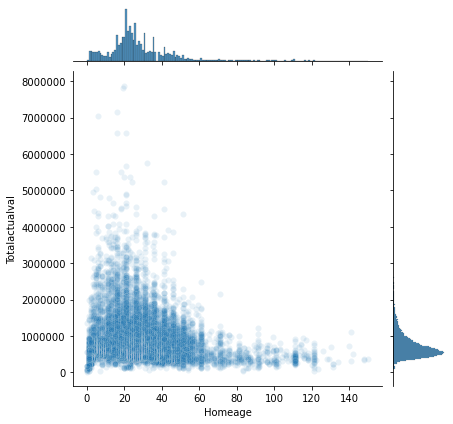

```python
sns.jointplot(data = Building_add_double,
              x = 'Homeage',
              y = 'Totalactualval',
              alpha = 0.1)
plt.ticklabel_format(style='plain', axis='y')
```

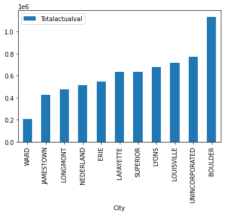

```python
Building_add_double.groupby(['City']).agg({'Totalactualval': 'median'}).sort_values(by = 'Totalactualval',ascending = True).plot(kind='bar')
```

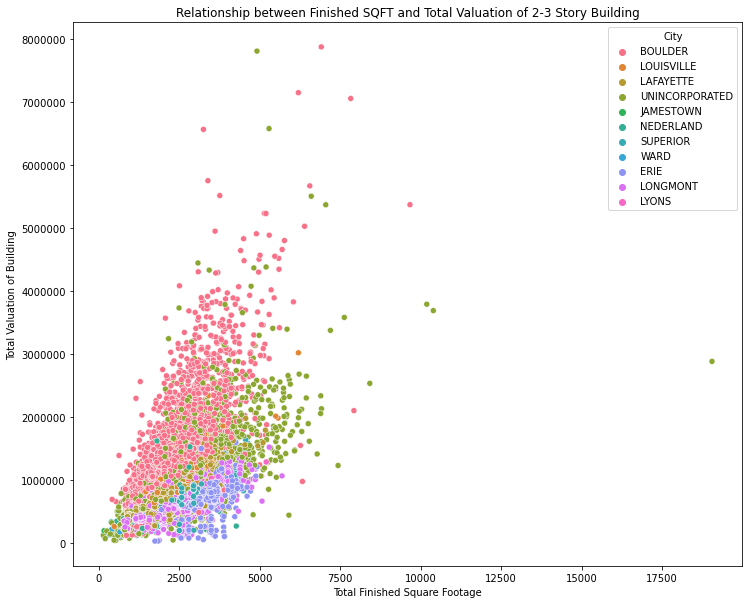

```python
fig, ax = plt.subplots(figsize=(12, 10))

ax = sns.scatterplot(x = 'Totalfinishedsf',
                     y = 'Totalactualval',
                     hue = 'City',
                     #style = 'City',
                     data = Building_add_double)
plt.ticklabel_format(style='plain', axis='y')

ax.set_ylabel('Total Valuation of Building')
ax.set_xlabel('Total Finished Square Footage')
ax.set_title('Relationship between Finished SQFT and Total Valuation of 2-3 Story Building')
```

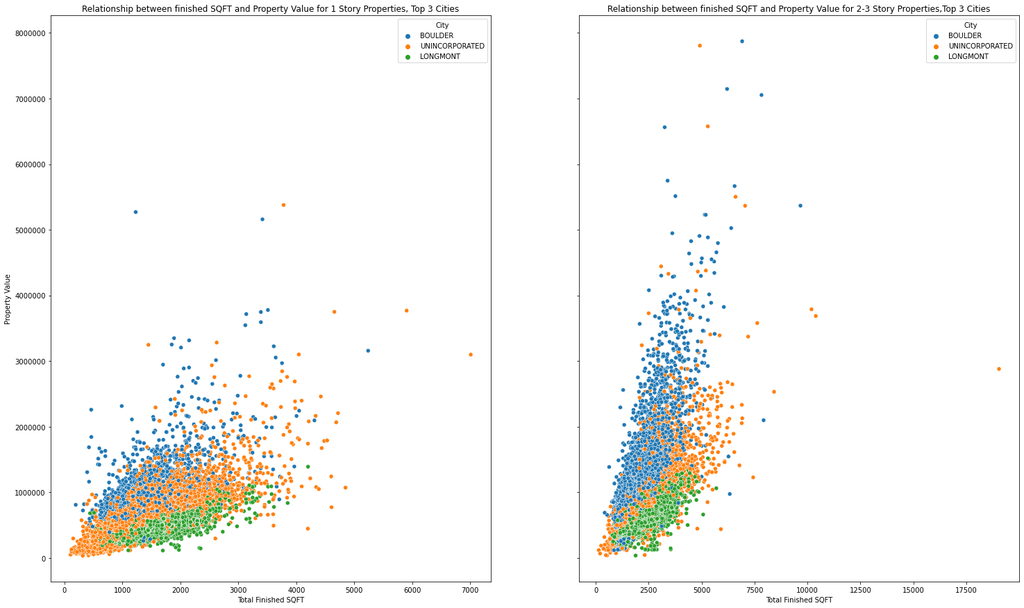

```python
ig, (axes_left, axes_right) = plt.subplots(1, 2,figsize=(25,15), sharey = True)

filt = (Building_add_single['City']=='LONGMONT') | (Building_add_single['City']=='UNINCORPORATED') | (Building_add_single['City']=='BOULDER')
Building_add_single1 = Building_add_single.loc[filt,:].copy()
filt = (Building_add_double['City']=='LONGMONT') | (Building_add_double['City']=='UNINCORPORATED') | (Building_add_double['City']=='BOULDER')
Building_add_double1 = Building_add_double.loc[filt,:].copy()


sns.scatterplot(x = 'Totalfinishedsf',
                     y = 'Totalactualval',
                     hue = 'City',
                     data = Building_add_single1,
               ax = axes_left)
axes_left.set_xlabel('Total Finished SQFT')
axes_left.set_ylabel('Property Value')
axes_left.set_title('Relationship between finished SQFT and Property Value for 1 Story Properties, Top 3 Cities')
plt.ticklabel_format(style='plain', axis='y')
sns.scatterplot(x = 'Totalfinishedsf',
                     y = 'Totalactualval',
                     hue = 'City',
                     data = Building_add_double1,
              ax = axes_right)
axes_right.set_xlabel('Total Finished SQFT')
axes_right.set_ylabel('Property Value')
axes_right.set_title('Relationship between finished SQFT and Property Value for 2-3 Story Properties,Top 3 Cities')
plt.ticklabel_format(style='plain', axis='y')
```

Exploring variables: Property Value, Property total finished sqft, number of bedrooms, bathrooms and basement(finished/unfinised or no basement)

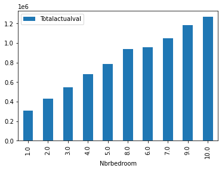

```python
Building_add_set2.groupby(['Nbrbedroom']).agg({'Totalactualval': 'median'}).sort_values(by = 'Totalactualval',ascending = True).plot(kind='bar')
```

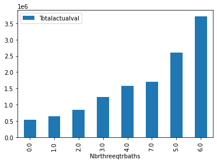

```python
Building_add_set2.groupby(['Nbrthreeqtrbaths']).agg({'Totalactualval': 'median'}).sort_values(by = 'Totalactualval',ascending = True).plot(kind='bar')
```

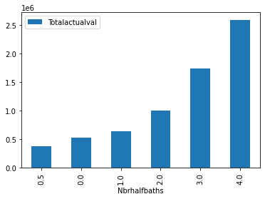

```python
Building_add_set2.groupby(['Nbrhalfbaths']).agg({'Totalactualval': 'median'}).sort_values(by = 'Totalactualval',ascending = True).plot(kind='bar')
```

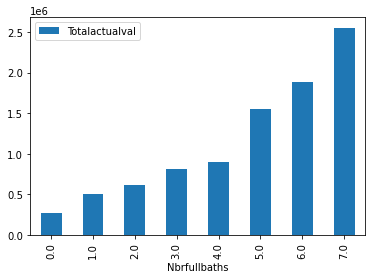

```python
Building_add_set2.groupby(['Nbrfullbaths']).agg({'Totalactualval': 'median'}).sort_values(by = 'Totalactualval',ascending = True).plot(kind='bar')
```

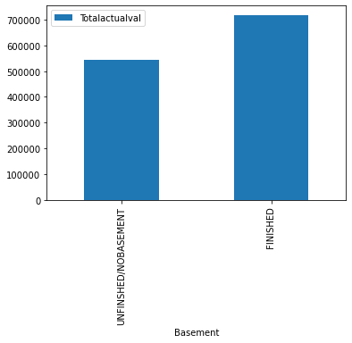

```python
Building_add_set2.groupby(['Basement']).agg({'Totalactualval': 'median'}).sort_values(by = 'Totalactualval',ascending = True).plot(kind='bar')
```

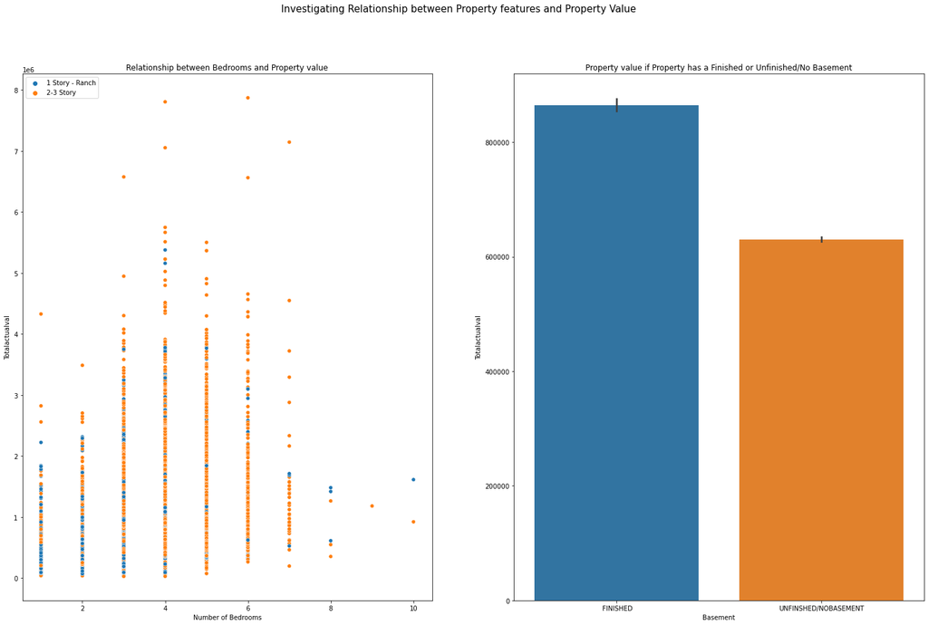

```python
fig, (axes_left, axes_right) = plt.subplots(1, 2,figsize=(25,15))

sns.scatterplot(x = 'Nbrbedroom',
               y = 'Totalactualval',
               hue = 'Designcodedscr',
               data = Building_add_set2,
               ax = axes_left)
plt.ticklabel_format(style='plain', axis='y')

sns.barplot(x = 'Basement',
    y = 'Totalactualval',
            data = Building_add_set2,
               ax = axes_right)


axes_left.set_xlabel('Number of Bedrooms')
axes_left.set_title('Relationship between Bedrooms and Property value')
axes_left.legend(loc = 'upper left')

axes_right.set_xlabel('Basement')
axes_right.set_title('Property value if Property has a Finished or Unfinished/No Basement')
fig.suptitle('Investigating Relationship between Property features and Property Value',fontsize=15)
```

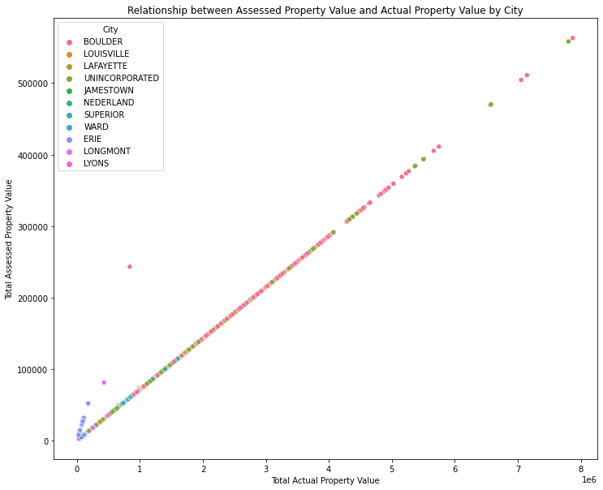

```python
Building_add_set1

fig, ax = plt.subplots(figsize=(12, 10))

ax = sns.scatterplot(x = 'Totalactualval',
                     y = 'Totalassessedval',
                     hue = 'City',
                     #style = 'type',
                     data = Building_add_set1)

ax.set_ylabel('Total Assessed Property Value')
ax.set_xlabel('Total Actual Property Value')
ax.set_title('Relationship between Assessed Property Value and Actual Property Value by City')
```

Bivariate Relationships:

1. Both actual property value and home age are right skewed. As the home age increases the property value declines.
2. The graph between city and property value shows that Boulder has the highest median property value for single story buildings followed by Unincorporated and Louisville.

Other:

1. From the graph exploring total finished sqft vs property value by city, we see that Boulder has the highest range of values and cities such as Ward, Longmont, Lyons and Erie have low values. Unincorportaed also has the large range of property sqft.

1. Total Actual Value : Mean value is 775075, Median value is 639700, Max and Min values are 7872360 and 27100 respectively.
2. Total Square Footage: Mean value is 2246, median is 2136 Max and Min values are 19044 and 144 respectively.
3. Home age: Mean and median home age is 26 and 24. Max home age is 150.
4. For 2-3 story homes, 3 cities have the most number of homes in data set: Longmont: 28%, Unincorporated: 18% and Boulder:19%

Bivariate Relationships:

Comparison of 1-Story and 2-3 Story Properties:

This graph has been filtered to top three cities represented in the data set: Boulder, Longmont and Unincorporated. We can see that in terms of price Boulder is at the top followed by unincorporated and then Longmont.There are outliers in both data sets that pull the mean sqft up.

Data Set 2: Exploring property value by property features:

Lastly relationship between totalactual property value and total assessed value is linear with some outliers.

## Part 2: Property Valuation

### Objective

In this portion, goal is to predict the value of a new single-family property given comparable sales data. One way we might estimate the value of a home is to look at the value of *k*-similar nearby homes that have recently sold. The average sales price of those *k* homes could then be used as the predicted valuation for our new home. This process is effectively how the K-Nearest Neighbor Algorithm (KNN) works for regression problems.

KNN is considered a supervised machine learning algorithm that can be used to solve both classification and regression problems. As shown above, we can be used to solve nonparametric regression problems such as predicting the price of a new home based on *similar* nearby homes.

Central factors used for property valuation:

- Location
- Living Area (SQFT)
- Age of the Home
- Finished Basement

### Read and Prepare the Sales Data

- Load the sales.csv
- Keep only qualified sales (sales.sales_cd == 'Q') and sales.price > 0.
- Keep only sales in the last 5 years (01/01/2015 and 12/31/2020)
- Join "sales" with the necessary data frames to add the following columns
  - nh, this is the neighborhood number that must be used to identify comparable sales by location.
  - totalActualVal
  - builtYear
  - EffectiveYear
  - TotalFinishedSF
  - A boolean flag (1/0) for if the basement is finished that you will need to create

```python
sales = pd.read_csv("../data-sets/sales.csv")
sales.head(3)
```

|  | strap | deedNum | Tdate | sales_cd | deed_type | price | status_cd |
| --- | --- | --- | --- | --- | --- | --- | --- |
| 0 | R0000005 | 416158 | 10/7/1980 12:00:00 AM | Q | WJ | 89500.0 | A |
| 1 | R0000005 | 1317705 | 7/26/1993 12:00:00 AM | Q | WD | 149900.0 | A |
| 2 | R0000005 | 2316275 | 7/18/2002 12:00:00 AM | Q | WD | 345000.0 | A |

```python
filt = (sales['sales_cd'] == 'Q') & (sales.price >0)
sales = sales.loc[filt,:].copy()

sales['Tdate'] = pd.to_datetime(sales['Tdate'])
```

```python
sales.columns = sales.columns.str.capitalize()
```

```python
filt = (sales['Tdate'] > '2015-01-01') & (sales['Tdate'] < '2020-12-31')
sales = sales[filt].copy()
```

```python
sales_building = sales.merge(buildings,
                           how = 'inner',
                           on = 'Strap')
```

```python
sales_building = sales_building[['Strap','Tdate','Price','Effectiveyear','Totalfinishedsf','Builtyear','Bsmttypedscr']].copy()
```

```python
sales_building = sales_building.merge(owner_add,
                           how = 'inner',
                           on = 'Strap')
sales_building = sales_building[['Strap','Tdate','Price','Effectiveyear','Totalfinishedsf','Builtyear','Bsmttypedscr','Nh']].copy()
```

```python
sales_building = sales_building.merge(values,
                           how = 'inner',
                           on = 'Strap')
sales_building = sales_building[['Strap','Tdate','Price','Effectiveyear','Totalfinishedsf','Builtyear','Bsmttypedscr','Nh','Totalactualval']].copy()
```

```python
sales_building['Basement'] = sales_building['Bsmttypedscr'].str.extract('( FINISHED)')
```

```python
sales_building['Basement'] = sales_building['Basement'].fillna("UNFINSHED/NOBASEMENT")
```

```python
sales_building['Bsmntflg'] = np.where(
    sales_building['Basement'] == 'UNFINSHED/NOBASEMENT', 0, 1)
#sales_building.drop(columns = ['Bsmttypedscr'],inplace = True)
```

```python
sales_building['home_age'] = 2020 - sales_building['Effectiveyear'].copy()
```

```python
sales_building.rename(columns = {'Totalfinishedsf':'finished_sqft','Bsmntflg':'finished_basement'},inplace = True)
```

```python
sales_building.head(5)
```

|  | Strap | Tdate | Price | Effectiveyear | finished_sqft | Builtyear | Bsmttypedscr | Nh | Totalactualval | Basement | finished_basement | home_age |
| --- | --- | --- | --- | --- | --- | --- | --- | --- | --- | --- | --- | --- |
| 0 | R0000013 | 2015-12-14 | 1315000.0 | 1995 | 3111 | 1973 | SUBTERRANEAN BASEMENT UNFINISHED AREA | 120.0 | 1838000 | UNFINSHED/NOBASEMENT | 0 | 25 |
| 1 | R0000017 | 2018-11-20 | 728500.0 | 1985 | 1213 | 1968 | SUBTERRANEAN BASEMENT FINISHED AREA | 120.0 | 876000 | FINISHED | 1 | 35 |
| 2 | R0000026 | 2017-02-15 | 1240000.0 | 1983 | 3022 | 1891 | SUBTERRANEAN BASEMENT FINISHED AREA | 102.0 | 1715000 | FINISHED | 1 | 37 |
| 3 | R0000028 | 2018-08-15 | 2350000.0 | 1985 | 1905 | 1945 | WALK-OUT BASEMENT FINISHED AREA | 103.0 | 2225500 | FINISHED | 1 | 35 |
| 4 | R0000038 | 2015-06-15 | 569900.0 | 1960 | 660 | 1900 | 0 | 109.0 | 668000 | UNFINSHED/NOBASEMENT | 0 | 60 |

### Property Valuation using KNN

- Function **predict_knn()** finds the k-most similar sales properties in the appraisal neighborhood (nh) and returns the average sale price for those *k* properties as the predicted value (y_hat).
- Write knn function from scratch, do not use sklearn.neighbors.KNeighborsRegressor.

#### KNN Regression Pseudo Code

Given a new data point:

1. Calculate the Euclidean distance between the new data point and all known datapoints in the dataset.
2. Select the *k* closest datapoints.
3. Average the target variable for the *k* closest data points.

Euclidean Distance formula for 3-dimenstions where p_1 and q_1 is finished_sqft, p2 and q_2 is home_age, and p3 and q_3 is finished_basement:

$$d(p,q)=\sqrt{(p_1-q_1)^2 + (p_2-q_2)^2 + (p_3-q_3)^2}$$

.

```python
import numpy as np
def predict_knn(sales_data, k=3, nh=200, finished_sqft=1500, home_age=5, finished_basement=False):

    # Filter down to our sales data to the provided neighborhood number, nh.
    sales_data = sales_data.loc[sales_data.Nh == nh].copy()


    # Calculate the Euclidean Distance for finished_sqft, home_age, and finished_basement for every sale in our nh.
    sales_data['distance1'] = (sales_data['finished_sqft'] - finished_sqft)**2
    sales_data['distance2'] = (sales_data['home_age'] - home_age)**2
    sales_data['distance3'] = (sales_data['finished_basement'] - finished_basement)**2
    sales_data['total_distance'] = np.sqrt(sales_data['distance1']+sales_data['distance2']+sales_data['distance3'])
    y_hat = sales_data.nsmallest(n=k,columns = ['total_distance'])
    return y_hat['Price'].mean()
```

### Test KNN function

Select 10 or more existing home valuations at random and compare the results of predict_knn() to the Accessors's provided valuation (In values.csv, the totalActualVal column). How do predictions perform relative to the Accessor's valuation as we try different values of *k*?

```python
sales_building.sample(10)
```

|  | Strap | Tdate | Price | Effectiveyear | finished_sqft | Builtyear | Bsmttypedscr | Nh | Totalactualval | Basement | finished_basement | home_age |
| --- | --- | --- | --- | --- | --- | --- | --- | --- | --- | --- | --- | --- |
| 4865 | R0081190 | 2020-12-03 | 476000.0 | 1985 | 1312 | 1979 | SUBTERRANEAN BASEMENT UNFINISHED AREA | 470.0 | 414700 | UNFINSHED/NOBASEMENT | 0 | 35 |
| 243 | R0003655 | 2019-10-30 | 1000000.0 | 1985 | 1393 | 1900 | 0 | 109.0 | 1062500 | UNFINSHED/NOBASEMENT | 0 | 35 |
| 4114 | R0060704 | 2015-05-01 | 380000.0 | 1993 | 1342 | 1993 | WALK-OUT BASEMENT FINISHED AREA | 911.0 | 554800 | FINISHED | 1 | 27 |
| 851 | R0012383 | 2020-03-12 | 799500.0 | 1994 | 2147 | 1968 | SUBTERRANEAN BASEMENT UNFINISHED AREA | 142.0 | 797000 | UNFINSHED/NOBASEMENT | 0 | 26 |
| 2345 | R0040181 | 2015-10-14 | 385000.0 | 1962 | 1691 | 1956 | 0 | 201.0 | 418500 | UNFINSHED/NOBASEMENT | 0 | 58 |
| 3623 | R0050288 | 2018-08-24 | 437000.0 | 2010 | 1339 | 1935 | 0 | 962.0 | 529200 | UNFINSHED/NOBASEMENT | 0 | 10 |
| 9078 | R0508942 | 2017-10-17 | 435000.0 | 2006 | 1410 | 2006 | SUBTERRANEAN BASEMENT UNFINISHED AREA | 450.0 | 576900 | UNFINSHED/NOBASEMENT | 0 | 14 |
| 10735 | R0606294 | 2019-03-01 | 397000.0 | 2016 | 2149 | 2016 | SUBTERRANEAN BASEMENT UNFINISHED AREA | 255.0 | 494200 | UNFINSHED/NOBASEMENT | 0 | 4 |
| 8776 | R0503867 | 2020-01-03 | 455000.0 | 2002 | 2404 | 2002 | GARDEN BASEMENT UNFINISHED AREA | 257.0 | 468600 | UNFINSHED/NOBASEMENT | 0 | 18 |
| 5859 | R0109271 | 2017-05-31 | 750000.0 | 2000 | 2615 | 1993 | GARDEN BASEMENT FINISHED AREA | 415.0 | 897400 | FINISHED | 1 | 20 |

```python
predict_test = sales_building.sample(10)
predict_test['Predicted_Price'] = round(predict_test.apply(lambda x: predict_knn(sales_building,k=15,nh=x['Nh'],finished_sqft=x['finished_sqft'],home_age=x['home_age'],finished_basement=x['finished_basement']), axis=1))
```

```python
predict_test['difference'] = round(((predict_test['Totalactualval'] - predict_test['Predicted_Price'])/predict_test['Totalactualval'])*100)
```

```python
predict_test
```

|  | Strap | Tdate | Price | Effectiveyear | finished_sqft | Builtyear | Bsmttypedscr | Nh | Totalactualval | Basement | finished_basement | home_age | Predicted_Price | difference |
| --- | --- | --- | --- | --- | --- | --- | --- | --- | --- | --- | --- | --- | --- | --- |
| 108 | R0001825 | 2019-01-31 | 1675000.0 | 2003 | 2924 | 1961 | 0 | 115.0 | 1778300 | UNFINSHED/NOBASEMENT | 0 | 17 | 1629907.0 | 8.0 |
| 501 | R0007410 | 2018-08-31 | 2340000.0 | 2000 | 3030 | 1925 | SUBTERRANEAN BASEMENT FINISHED AREA | 170.0 | 2453900 | FINISHED | 1 | 20 | 1953667.0 | 20.0 |
| 2087 | R0036500 | 2019-08-20 | 915000.0 | 1995 | 2305 | 1962 | 0 | 145.0 | 822880 | UNFINSHED/NOBASEMENT | 0 | 25 | 900000.0 | -9.0 |
| 11534 | R0610045 | 2019-09-16 | 560000.0 | 2018 | 3180 | 2018 | SUBTERRANEAN BASEMENT UNFINISHED AREA | 440.0 | 608100 | UNFINSHED/NOBASEMENT | 0 | 2 | 589487.0 | 3.0 |
| 4030 | R0057656 | 2015-05-06 | 205000.0 | 1985 | 888 | 1985 | 0 | 960.0 | 325440 | UNFINSHED/NOBASEMENT | 0 | 35 | 320847.0 | 1.0 |
| 2143 | R0037619 | 2015-11-30 | 430000.0 | 1985 | 1032 | 1956 | 0 | 154.0 | 691700 | UNFINSHED/NOBASEMENT | 0 | 35 | 702438.0 | -2.0 |
| 3746 | R0052934 | 2019-08-30 | 880000.0 | 1998 | 1030 | 1915 | 0 | 825.0 | 632530 | UNFINSHED/NOBASEMENT | 0 | 22 | 481000.0 | 24.0 |
| 2690 | R0042597 | 2016-05-26 | 520000.0 | 2005 | 1292 | 1951 | 0 | 201.0 | 517870 | UNFINSHED/NOBASEMENT | 0 | 15 | 410800.0 | 21.0 |
| 4537 | R0071767 | 2015-11-02 | 489200.0 | 1990 | 2278 | 1979 | SUBTERRANEAN BASEMENT FINISHED AREA | 136.0 | 727600 | FINISHED | 1 | 30 | 709547.0 | 2.0 |
| 11669 | R0610493 | 2020-12-10 | 455800.0 | 2020 | 955 | 2020 | 0 | 450.0 | 416800 | UNFINSHED/NOBASEMENT | 0 | 0 | 418167.0 | -0.0 |

## Part III: Ethics Review

Whenever we are modeling our data, it's critical that we take time to consider the impact our algorithms have on people's lives. Considerations:

1. Possible source of bias that exist might exist in this dataset and impact our estimated valuation
2. What potential harm could arise due to how our knn regression algorithm works? For example, what if *k* is too low or too high? What impact can outliers have? Would it make sense to normalize (e.g. standardize our values between 0 and 1) for our data points (sqft, age, basement) before calculating Euclidean Distance?
3. Should we have an appeal process for people that may be harmed by the results of our model?
1. One potential bias here is calculating the home age based on effective year. Effective year variable updates the age of a home based on renovations. However, all renovations are not equal. Depending on the updates and the quality of renovation, some properties might get an updated age but the condition of home might not reflect the updated age. This means that the property value would increase when it should not. Another potential issue is that we are using this sample to created an algorithm for predicted values, how do we know that the assessed values in this sample are accurate or what method was used to assess them, the bias that went into assessing these properties will cary over to our algorithm as well.
2. If the k value is high, we might factor in properties that have either very high or very low values that may pull up or down the mean and incorrectly assess the property value. If we normalize the value then we scaling based on these extreme maximum and minimum values and can prevent the issue of shifting the mean to one side.
3. An appeal process would provide a method to re-assess a property value for owners who think that their property has been evaluated incorrectly. The process of assessing property value should also be made public so that all property owners are informed and can raise an issue if they think that there is an error in this method.